# Project 2: Data Mining, Classification, Prediction

SDS322E

# Mining, Classification, Prediction

## Shilpi Karan sk46966

### Introduction

The dataset I chose for this project is Budget Share of Food for Spanish Households. There are 6 variables in the dataset. wfood is the percentage of total expenditure which the household has spent on food, totexp is the total expenditure of the household, age is the age of reference person in the household, size is the size of the household, town is the size of the town where the household is placed categorized into 5 groups: 1 for small towns, 5 for big ones, and sex is the sex of reference person, man or woman. I found the data from a website that has a list of R datasets from a few common packages called https://vincentarelbundock.github.io/Rdatasets/datasets.html. The variables are measuring different aspects of a household that affect food related expenses. There are 23972 observations. There are 20624 observations for the man group and 3347 observations for the woman group for the binary variable, sex.

```r
library(tidyverse)
library(dplyr)
library(ggplot2)

data <- read_csv("https://vincentarelbundock.github.io/Rdatasets/csv/Ecdat/BudgetFood.csv")
data
```

```
## # A tibble: 23,972 × 7
##       X1 wfood  totexp   age  size  town sex
##    <dbl> <dbl>   <dbl> <dbl> <dbl> <dbl> <chr>
##  1     1 0.468 1290941    43     5     2 man
##  2     2 0.313 1277978    40     3     2 man
##  3     3 0.376  845852    28     3     2 man
##  4     4 0.440  527698    60     1     2 woman
##  5     5 0.404 1103220    37     5     2 man
##  6     6 0.199 1768128    35     4     2 man
##  7     7 0.159 1107529    40     4     2 man
##  8     8 0.519  737959    68     2     2 woman
##  9     9 0.339 1019848    43     9     2 man
## 10    10 0.272 2149883    51     7     2 man
## # … with 23,962 more rows
```

```r
table(data$sex)
```

```
##
##   man woman
## 20624  3347
```

### Cluster Analysis

```r
library(cluster)

Data <- data %>% select(-1)
Data <- Data %>% select(-6)
Data
```

```
## # A tibble: 23,972 × 5
##    wfood  totexp   age  size  town
##    <dbl>   <dbl> <dbl> <dbl> <dbl>
##  1 0.468 1290941    43     5     2
##  2 0.313 1277978    40     3     2
##  3 0.376  845852    28     3     2
##  4 0.440  527698    60     1     2
##  5 0.404 1103220    37     5     2
##  6 0.199 1768128    35     4     2
##  7 0.159 1107529    40     4     2
##  8 0.519  737959    68     2     2
##  9 0.339 1019848    43     9     2
## 10 0.272 2149883    51     7     2
## # … with 23,962 more rows
```

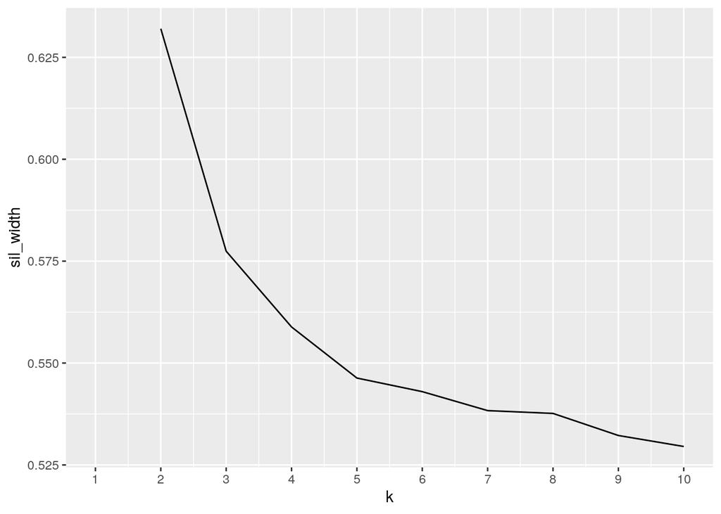

```r
sil_width <- vector()
for (i in 2:10) {
    kms <- kmeans(Data, centers = i)
    sil <- silhouette(kms$cluster, dist(Data))
    sil_width[i] <- mean(sil[, 3])
}

ggplot() + geom_line(aes(x = 1:10, y = sil_width)) + scale_x_continuous(name = "k",
    breaks = 1:10)
```

```r
data_pam <- data %>% pam(k = 2)
data_pam$silinfo$avg.width
```

```
## [1] 0.5612613
```

```r
data_pam
```

```
## Medoids:
##         ID    X1     wfood  totexp age size town sex
## [1,] 12425 12425 0.2034951 1253141  43    5    5  NA
## [2,] 12139 12139 0.4061548  516089  32    4    4  NA
## Clustering vector:
##   [1] 1 1 2 2 1 1 1 2 1 1 1 1 2 2 1 1 1 1 1 2 2 2 2 2 1 1 1 1 2 2 2 2 2 2 2 1 1
##  [38] 2 1 1 2 1 1 1 1 2 1 2 2 2 2 2 2 2 1 1 1 1 1 1 2 2 2 2 1 1 1 2 1 2 2 1 1 2
##  [75] 2 2 1 2 2 2 2 2 2 2 2 1 1 1 1 1 2 2 2 2 2 2 1 2 2 1
##  [ reached getOption("max.print") -- omitted 23872 entries ]
## Objective function:
##    build     swap
## 316307.6 286880.5
##
## Available components:
##  [1] "medoids"    "id.med"     "clustering" "objective"  "isolation"
##  [6] "clusinfo"   "silinfo"    "diss"       "call"       "data"
```

```r
# Clustering with three measurements

clust_dat <- data %>% dplyr::select(wfood, totexp, age)
set.seed(322)
pam1 <- clust_dat %>% pam(k = 2)
pam1
```

```
## Medoids:
##        ID     wfood  totexp age
## [1,] 5321 0.2923381 1252960  51
## [2,] 5161 0.5799114  516134  38
## Clustering vector:
##   [1] 1 1 2 2 1 1 1 2 1 1 1 1 2 2 1 1 1 1 1 2 2 2 2 2 1 1 1 1 2 2 2 2 2 2 2 1 1
##  [38] 2 1 1 2 1 1 1 1 2 1 2 2 2 2 2 2 2 1 1 1 1 1 1 2 2 2 2 1 1 1 2 1 2 2 1 1 2
##  [75] 2 2 1 2 2 2 2 2 2 2 2 1 1 1 1 1 2 2 2 2 2 2 1 2 2 1
##  [ reached getOption("max.print") -- omitted 23872 entries ]
## Objective function:
##    build     swap
## 292578.3 265303.1
##
## Available components:
##  [1] "medoids"    "id.med"     "clustering" "objective"  "isolation"
##  [6] "clusinfo"   "silinfo"    "diss"       "call"       "data"
```

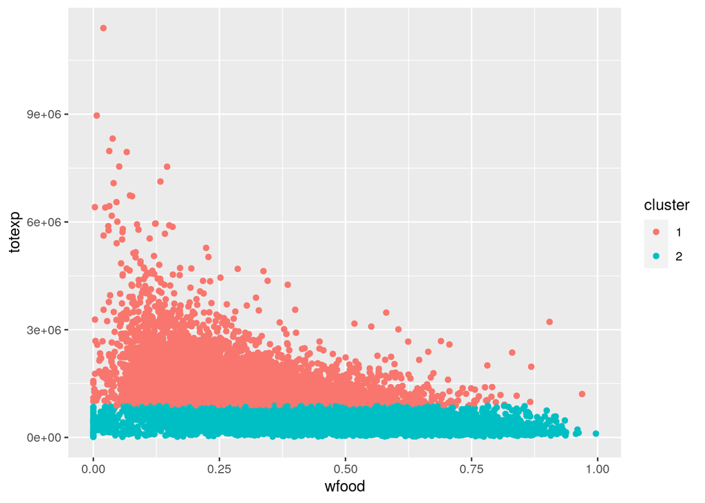

```r
pamclust <- clust_dat %>% mutate(cluster = as.factor(pam1$clustering))  #save the cluster solution in your dataset
pamclust %>% ggplot(aes(wfood, totexp, age, sex, color = cluster)) +
    geom_point()  #visualize it
```

```r
pamclust %>% group_by(cluster) %>% summarize_if(is.numeric, mean,
    na.rm = T)
```

```
## # A tibble: 2 × 4
##   cluster wfood   totexp   age
##   <fct>   <dbl>    <dbl> <dbl>
## 1 1       0.282 1445066.  46.1
## 2 2       0.438  508053.  53.3
```

```r
data %>% slice(pam1$id.med)
```

```
## # A tibble: 2 × 7
##      X1 wfood  totexp   age  size  town sex
##   <dbl> <dbl>   <dbl> <dbl> <dbl> <dbl> <chr>
## 1  5321 0.292 1252960    51     6     4 man
## 2  5161 0.580  516134    38     9     4 man
```

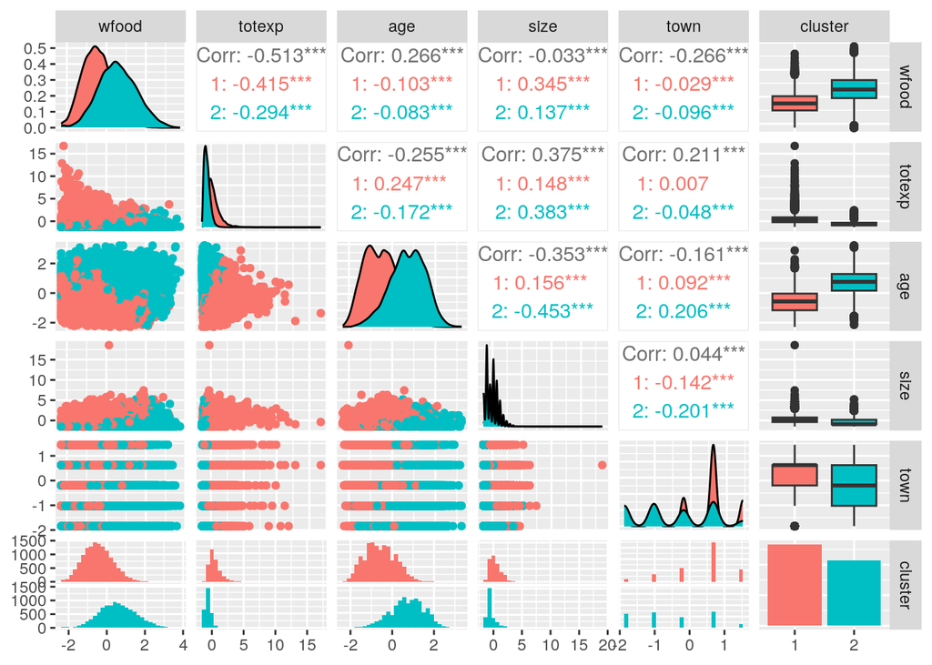

```r
# Clustering with all measurements

final <- data %>% select(-X1) %>% select(-sex) %>% scale %>%
    as.data.frame
pam2 <- final %>% pam(2)

# now that we ran PAM, save the cluster assignment in the
# dataset
final <- final %>% mutate(cluster = as.factor(pam2$clustering))


library(GGally)
ggpairs(final, aes(color = cluster))
```

It seemed appropriate to only have 2 clusters for the data based on the silhouette width. There seems to be 2 distinct clusters. The goodness of fit is in the center of the clusters which shows that it is a decent goodness of fit.

### Dimensionality Reduction with PCA

```r
data1 <- data %>% select(-X1, -sex)
data1
```

```
## # A tibble: 23,972 × 5
##    wfood  totexp   age  size  town
##    <dbl>   <dbl> <dbl> <dbl> <dbl>
##  1 0.468 1290941    43     5     2
##  2 0.313 1277978    40     3     2
##  3 0.376  845852    28     3     2
##  4 0.440  527698    60     1     2
##  5 0.404 1103220    37     5     2
##  6 0.199 1768128    35     4     2
##  7 0.159 1107529    40     4     2
##  8 0.519  737959    68     2     2
##  9 0.339 1019848    43     9     2
## 10 0.272 2149883    51     7     2
## # … with 23,962 more rows
```

```r
data1_nums <- data1 %>% select_if(is.numeric) %>% scale
rownames(data1_nums) <- data1$Name
data1_pca <- princomp(data1_nums)
names(data1_pca)
```

```
## [1] "sdev"     "loadings" "center"   "scale"    "n.obs"    "scores"   "call"
```

```r
summary(data1_pca, loadings = T)
```

```
## Importance of components:
##                           Comp.1    Comp.2    Comp.3    Comp.4     Comp.5
## Standard deviation     1.4258658 1.0452323 0.9044148 0.8388863 0.59370980
## Proportion of Variance 0.4066356 0.2185112 0.1636000 0.1407519 0.07050121
## Cumulative Proportion  0.4066356 0.6251468 0.7887469 0.9294988 1.00000000
##
## Loadings:
##        Comp.1 Comp.2 Comp.3 Comp.4 Comp.5
## wfood   0.487  0.451  0.388  0.282  0.574
## totexp -0.558        -0.430  0.329  0.628
## age     0.445 -0.315 -0.357  0.719 -0.242
## size   -0.384  0.672         0.419 -0.467
## town   -0.325 -0.495  0.727  0.346
```

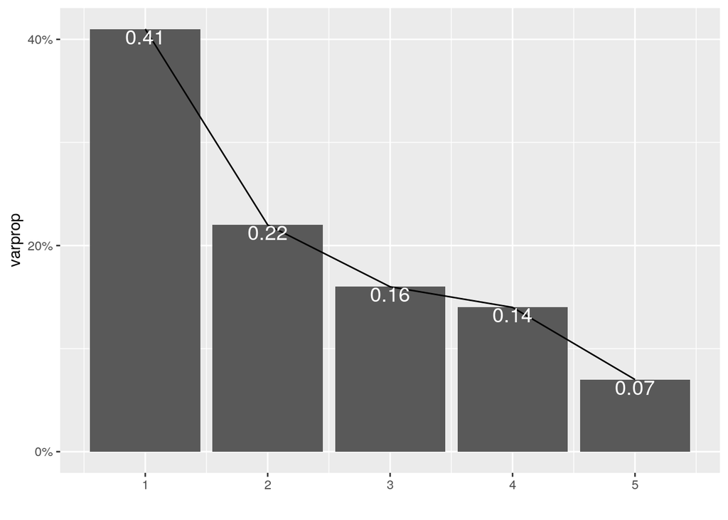

```r
eigval <- data1_pca$sdev^2
varprop = round(eigval/sum(eigval), 2)
ggplot() + geom_bar(aes(y = varprop, x = 1:5), stat = "identity") +
    xlab("") + geom_path(aes(y = varprop, x = 1:5)) + geom_text(aes(x = 1:5,
    varprop, label = round(varprop, 2)), vjust = 1, col = "white",
    size = 5) + scale_y_continuous(breaks = seq(0, 0.6, 0.2),
    labels = scales::percent) + scale_x_continuous(breaks = 1:10)
```

```r
round(cumsum(eigval)/sum(eigval), 2)
```

```
## Comp.1 Comp.2 Comp.3 Comp.4 Comp.5
##   0.41   0.63   0.79   0.93   1.00
```

```r
eigval
```

```
##    Comp.1    Comp.2    Comp.3    Comp.4    Comp.5
## 2.0330933 1.0925105 0.8179660 0.7037303 0.3524913
```

```r
summary(data1_pca, loadings = T)
```

```
## Importance of components:
##                           Comp.1    Comp.2    Comp.3    Comp.4     Comp.5
## Standard deviation     1.4258658 1.0452323 0.9044148 0.8388863 0.59370980
## Proportion of Variance 0.4066356 0.2185112 0.1636000 0.1407519 0.07050121
## Cumulative Proportion  0.4066356 0.6251468 0.7887469 0.9294988 1.00000000
##
## Loadings:
##        Comp.1 Comp.2 Comp.3 Comp.4 Comp.5
## wfood   0.487  0.451  0.388  0.282  0.574
## totexp -0.558        -0.430  0.329  0.628
## age     0.445 -0.315 -0.357  0.719 -0.242
## size   -0.384  0.672         0.419 -0.467
## town   -0.325 -0.495  0.727  0.346
```

```r
eig1 <- data1 %>% cor %>% eigen
eig1
```

```
## eigen() decomposition
## $values
## [1] 2.0331781 1.0925561 0.8180002 0.7037596 0.3525060
##
## $vectors
##            [,1]        [,2]        [,3]       [,4]         [,5]
## [1,]  0.4872300  0.45077333  0.38841328 -0.2818922 -0.573656936
## [2,] -0.5576229 -0.03224547 -0.42996886 -0.3292304 -0.628292138
## [3,]  0.4452671 -0.31530749 -0.35696592 -0.7186129  0.241845433
## [4,] -0.3844101  0.67161643  0.08750008 -0.4193242  0.466552481
## [5,] -0.3250073 -0.49525367  0.72744826 -0.3462756 -0.002505867
```

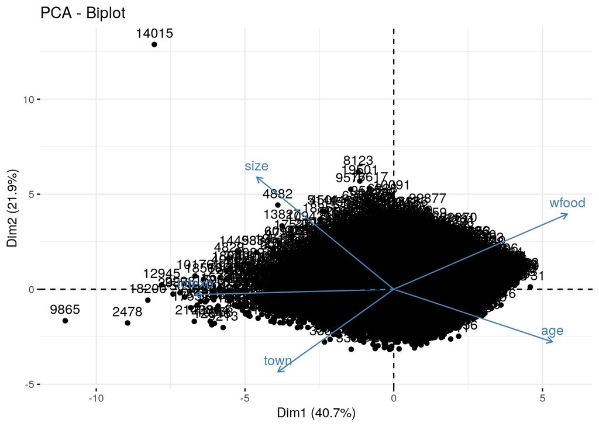

```r
library(factoextra)
fviz_pca_biplot(data1_pca)
```

Only some of the total variance is explained by these PCs. A high score on each PC retained means that the data is varies a lot. In relation to this dataset, since there is a high pc score, it means that the expenses varies a lot in terms of every other variable in the dataset.

### Linear Classifier

```r
# linear classifier code here

data$sex <- ifelse(data$sex == "man", 1, 0)
data
```

```
## # A tibble: 23,972 × 7
##       X1 wfood  totexp   age  size  town   sex
##    <dbl> <dbl>   <dbl> <dbl> <dbl> <dbl> <dbl>
##  1     1 0.468 1290941    43     5     2     1
##  2     2 0.313 1277978    40     3     2     1
##  3     3 0.376  845852    28     3     2     1
##  4     4 0.440  527698    60     1     2     0
##  5     5 0.404 1103220    37     5     2     1
##  6     6 0.199 1768128    35     4     2     1
##  7     7 0.159 1107529    40     4     2     1
##  8     8 0.519  737959    68     2     2     0
##  9     9 0.339 1019848    43     9     2     1
## 10    10 0.272 2149883    51     7     2     1
## # … with 23,962 more rows
```

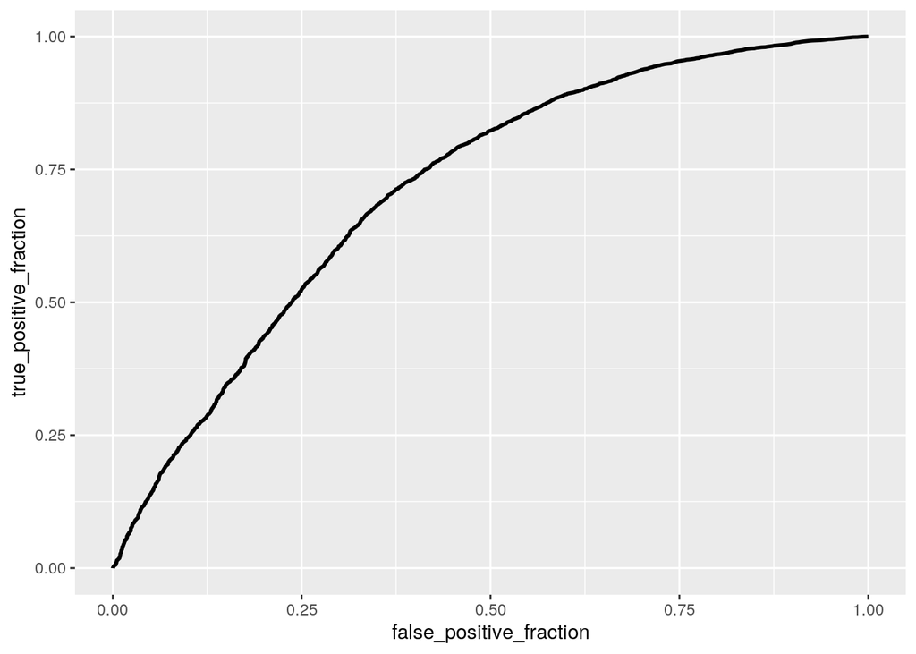

```r
library(pROC)
library(plotROC)
ROCplot <- ggplot() + geom_roc(aes(d = data$sex, m = data$wfood +
    data$totexp + data$age + data$size + data$town), n.cuts = 0)
ROCplot
```

```r
calc_auc(ROCplot)
```

```
##   PANEL group       AUC
## 1     1    -1 0.7153697
```

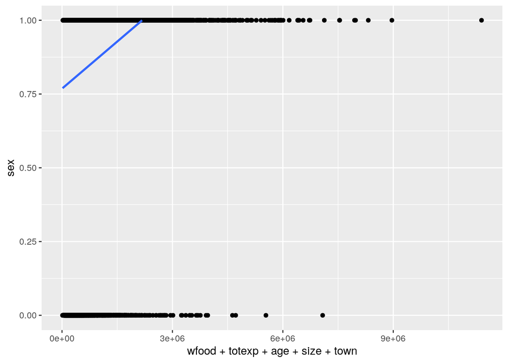

```r
data %>% ggplot(aes(wfood + totexp + age + size + town, sex)) +
    geom_point() + geom_smooth(method = "lm", se = F) + ylim(0,
    1)
```

```r
fit <- lm(sex ~ wfood + totexp + age + size + town, data = data)
score <- predict(fit)
score %>% round(3)
```

```
##     1     2     3     4     5     6     7     8     9    10    11    12    13
## 1.006 0.907 0.929 0.709 1.014 0.992 0.942 0.748 1.189 1.113 0.950 1.048 0.976
##    14    15    16    17    18    19    20    21    22    23    24    25    26
## 0.796 0.900 1.080 0.855 0.847 1.057 0.868 0.829 0.711 0.817 0.998 0.830 1.001
##    27    28    29    30    31    32    33    34    35    36    37    38    39
## 1.060 1.041 1.011 0.745 0.987 0.913 0.948 0.828 0.860 0.994 1.291 0.985 0.851
##    40    41    42    43    44    45    46    47    48    49    50    51    52
## 1.141 0.739 1.102 0.960 0.923 0.968 0.776 1.050 0.748 0.867 0.783 0.741 0.785
##    53    54    55    56    57    58    59    60    61    62    63    64    65
## 0.894 0.904 1.001 0.751 0.930 0.858 1.086 0.902 0.702 0.905 0.769 0.670 0.807
##    66    67    68    69    70    71    72    73    74    75    76    77    78
## 1.017 1.078 0.730 0.924 0.920 0.855 1.036 0.938 0.709 0.902 0.921 1.079 0.937
##    79    80    81    82    83    84    85    86    87    88    89    90    91
## 0.830 0.774 0.843 0.807 0.737 1.016 0.876 0.944 1.010 0.986 1.103 1.006 0.654
##    92    93    94    95    96    97    98    99   100
## 0.848 0.900 0.720 0.692 0.713 0.976 0.675 0.664 0.927
##  [ reached getOption("max.print") -- omitted 23871 entries ]
```

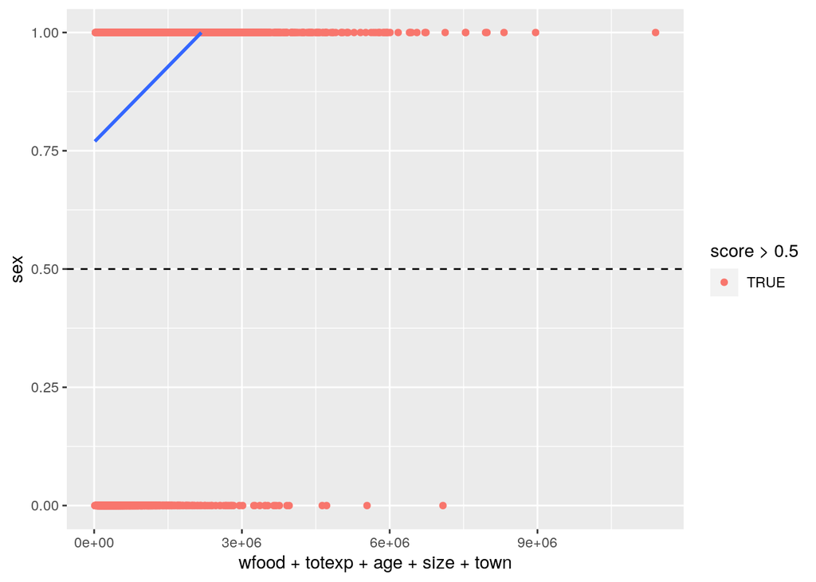

```r
data %>% mutate(score = 1) %>% ggplot(aes(wfood + totexp + age +
    size + town, sex)) + geom_point(aes(color = score > 0.5)) +
    geom_smooth(method = "lm", se = F) + ylim(0, 1) + geom_hline(yintercept = 0.5,
    lty = 2)
```

```r
class_diag <- function(score, truth, positive, cutoff = 0.5) {

    pred <- factor(score > cutoff, levels = c("TRUE", "FALSE"))
    truth <- factor(truth == positive, levels = c("TRUE", "FALSE"))
}
# summarise_all(diags,mean)
```

```r
# cross-validation of linear classifier here
data$sex <- ifelse(data$sex == "man", 1, 0)
data$X1 <- NULL
data
```

```
## # A tibble: 23,972 × 6
##    wfood  totexp   age  size  town   sex
##    <dbl>   <dbl> <dbl> <dbl> <dbl> <dbl>
##  1 0.468 1290941    43     5     2     0
##  2 0.313 1277978    40     3     2     0
##  3 0.376  845852    28     3     2     0
##  4 0.440  527698    60     1     2     0
##  5 0.404 1103220    37     5     2     0
##  6 0.199 1768128    35     4     2     0
##  7 0.159 1107529    40     4     2     0
##  8 0.519  737959    68     2     2     0
##  9 0.339 1019848    43     9     2     0
## 10 0.272 2149883    51     7     2     0
## # … with 23,962 more rows
```

```r
fit <- glm(sex ~ wfood + totexp + age + size + town, data = data,
    family = "binomial")  #fit model
prob <- predict(fit, type = "response")
prob
```

[output not shown]

```r
class_diag(prob, data$sex, positive = 1)

set.seed(1234)
k = 10  #choose number of folds
Data <- data[sample(nrow(data)), ]  #randomly order rows
folds <- cut(seq(1:nrow(data)), breaks = k, labels = F)  #create folds
diags <- NULL
for (i in 1:k) {
    ## Create training and test sets
    train <- Data[folds != i, ]
    test <- Data[folds == i, ]
    truth <- test$sex  ## Truth labels for fold i
    ## Train model on training set (all but fold i)
    fit <- glm(sex ~ wfood + totexp + age + size + town, data = train,
        family = "binomial")
    ## Test model on test set (fold i)
    probs <- predict(fit, newdata = test, type = "response")
    ## Get diagnostics for fold i
    diags <- rbind(diags, class_diag(probs, truth, positive = 1))
}

class_diag <- function(score, truth, positive, cutoff = 0.5) {

    pred <- factor(score > cutoff, levels = c("TRUE", "FALSE"))
    truth <- factor(truth == positive, levels = c("TRUE", "FALSE"))
}
# summarize_all(diags,mean) #average diagnostics across all k
# folds
```

### Non-Parametric Classifier

[figure not shown]

```r
library(caret)
library(dplyr)
library(rpart)
library(rpart.plot)
fit <- rpart(sex ~ wfood + totexp + age + size + town, data = data)
rpart.plot(fit)

fit <- rpart(sex ~ totexp + age + size + town, data = data)
rpart.plot(fit)
```

```r
fit <- rpart(sex ~ age + size + town, data = data)
rpart.plot(fit)

fit <- rpart(sex ~ size + town, data = data)
rpart.plot(fit)

fit <- rpart(sex ~ town, data = data)
rpart.plot(fit)

# rpart.plot(fit$finalModel)
```

[output not shown]

```r
# cross-validation of np classifier here
# data$sex<-ifelse(data$sex=='man',1,0)
na.exclude(data)
```

```
## # A tibble: 23,971 × 6
##    wfood  totexp   age  size  town   sex
##    <dbl>   <dbl> <dbl> <dbl> <dbl> <dbl>
##  1 0.468 1290941    43     5     2     0
##  2 0.313 1277978    40     3     2     0
##  3 0.376  845852    28     3     2     0
##  4 0.440  527698    60     1     2     0
##  5 0.404 1103220    37     5     2     0
##  6 0.199 1768128    35     4     2     0
##  7 0.159 1107529    40     4     2     0
##  8 0.519  737959    68     2     2     0
##  9 0.339 1019848    43     9     2     0
## 10 0.272 2149883    51     7     2     0
## # … with 23,961 more rows
```

```r
set.seed(1234)
cv <- trainControl(method = "cv", number = 10, classProbs = T,
    savePredictions = T)
# fit <- train(sex~wfood+totexp+age+size+town, data=data,
# trControl=cv, method='rpart') class_diag(fit$pred$man,
# fit$pred$woman, positive='man')
```

### Regression/Numeric Prediction

```r
fit <- lm(wfood ~ ., data = data)
yhat <- predict(fit)
cbind(yhat, y = data$wfood)
```

```
##                   yhat           y
##     [1,]  0.3552176790 0.467699143
##     [2,]  0.3058915385 0.313022603
##     [3,]  0.3398819924 0.376481938
##     [4,]  0.4077233987 0.439690884
##     [5,]  0.3682970158 0.403614873
##     [6,]  0.2497995571 0.199250281
##     [7,]  0.3517860089 0.158789522
##     [8,]  0.4181598373 0.519465174
##     [9,]  0.4820505233 0.339172112
##    [10,]  0.2983729785 0.272228768
##    [11,]  0.3200680731 0.247067479
##    [12,]  0.4392208417 0.359902039
##    [13,]  0.4789610680 0.524726852
##    [14,]  0.4419201631 0.532859890
```

[output cut: 37 more lines]

```r
mean((data$wfood - yhat)^2)
```

```
## [1] 0.02282064
```

```r
set.seed(1234)
k = 5
data <- data[sample(nrow(data)), ]
folds <- cut(seq(1:nrow(data)), breaks = k, labels = F)
diags <- NULL
for (i in 1:k) {
    train <- data[folds != i, ]
    test <- data[folds == i, ]
    fit <- lm(wfood ~ ., data = train)
    yhat <- predict(fit, newdata = test)
    diags <- mean((test$wfood - yhat)^2)
}
mean(diags)
```

```
## [1] 0.01816054
```

This model does not show signs of overfititng. The MSE is lower in the cross validation which means there is not overfitting. The first part of this section involved fitting a linear regression model to the entire dataset, predicting food expenses from all other variables.

### Python

```r
library(reticulate)
use_python("/usr/bin/python3")

plot <- import("matplotlib")
plot$use("Agg", force = TRUE)

# py$data1

s <- "Shilpi"
# cat(c(s,py$s))
```

```python
#data1=r.data
#data1
#print(r.data.head())

k="Karan"
print(r.s,k)
```

```
## Shilpi Karan
```